# Softmax and Logistic Regression

In this tutorial, we are going to implement a Softmax Regression as a multinomial class alongside a Logistic Regression using the binomial class by applicating them on the famous MNIST data set.

# Data Import

First, we import and extract the MNIST data

```r
setwd("C:/Users/gabym/Desktop/Semestre 3 UPPA/Machine Learning/MATERIAL_STUDENT/Mnist/")
file_training_set_image <- "train-images-idx3-ubyte/train-images.idx3-ubyte"
file_training_set_label <- "train-labels-idx1-ubyte/train-labels.idx1-ubyte"
file_test_set_image <- "t10k-images-idx3-ubyte/t10k-images.idx3-ubyte"
file_test_set_label <- "t10k-labels-idx1-ubyte/t10k-labels.idx1-ubyte"

nb_Chiffre <- 1000
nb_Pixel <- 28

extract_images <- function(file, nbimages = NULL) {
  if (is.null(nbimages)) { # We extract all images
    nbimages <- as.numeric(paste("0x", paste(readBin(file, "raw", n = 8)[5:8], collapse = ""), sep = ""))
  }
  nbrows <- as.numeric(paste("0x", paste(readBin(file, "raw", n = 12)[9:12], collapse = ""), sep = ""))
  nbcols <- as.numeric(paste("0x", paste(readBin(file, "raw", n = 16)[13:16], collapse = ""), sep = ""))
  raw <- readBin(file, "raw", n = nbimages * nbrows * nbcols + 16)[-(1:16)]
  return(array(as.numeric(paste("0x", raw, sep="")), dim = c(nbcols, nbrows, nbimages)))
}
extract_labels <- function(file) {
  nbitem <- as.numeric(paste("0x", paste(readBin(file, "raw", n = 8)[5:8], collapse = ""), sep = ""))
  raw <- readBin(file, "raw", n = nbitem + 8)[-(1:8)]
  return(as.numeric(paste("0x", raw, sep="")))
}

labels_training_set <- extract_labels(file_training_set_label)
labels_test_set <- extract_labels(file_test_set_label)
images_training_set <- extract_images(file_training_set_image, 60000)
images_training_set=t(matrix(images_training_set, dim(images_training_set)[1]*dim(images_training_set)[2], dim(images_training_set)[3]))

# x <-images_training_set
# y <- labels_training_set
images_test_set <- extract_images(file_test_set_image, 1000)
images_test_set=t(matrix(images_test_set, dim(images_test_set)[1]*dim(images_test_set)[2], dim(images_test_set)[3]))
```

As we can see, we are facing a dimensional problem and so the need to use a penalized regression.

# Softmax Regression

## Ridge Regression

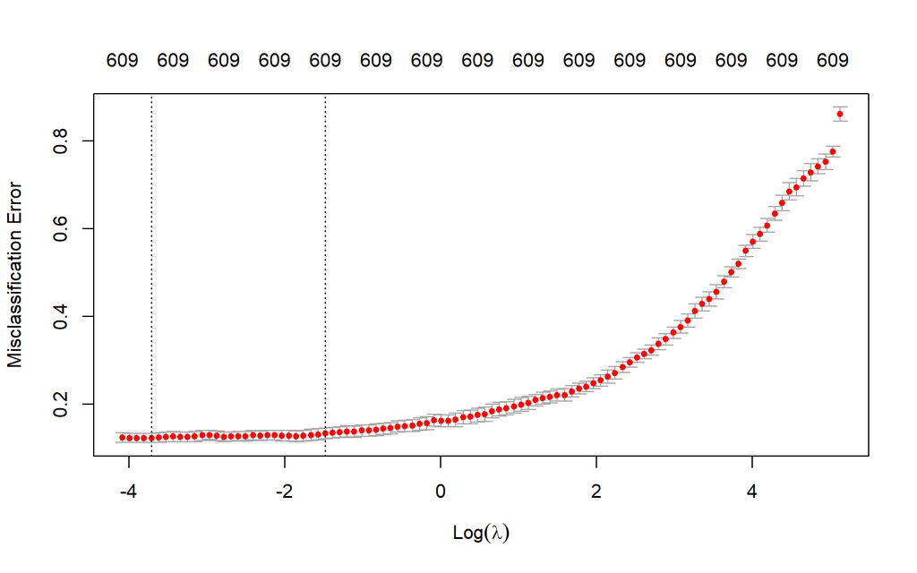

```r
## multinomiale
library(glmnet)
# tune <- cv.glmnet(x,y,alpha=0)
# plot(tune)

x <- images_training_set
y <- labels_training_set

temporary <- x[1:1000,]
temporary2<- y[1:1000]

# Ridge
multinomial_reg <- cv.glmnet(temporary, temporary2, family = "multinomial", type.measure = "class", alpha = 0)
plot(multinomial_reg)
```

```r
pred = predict(multinomial_reg, images_test_set, s=multinomial_reg$lambda.min, type="class")
# pred
mean(labels_test_set[1:1000] == pred)
```

```
[1] 0.833
```

## Lasso Regression

We then applied $lasso$ with an $\alpha = 1$, and the result came as follow

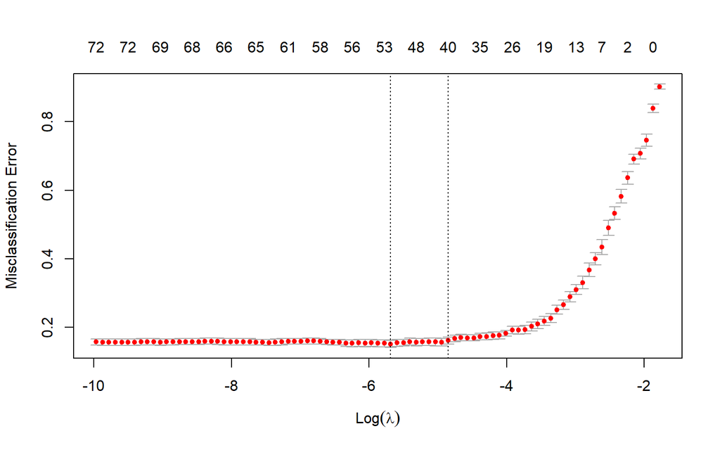

```r
# Lasso
binomimale_reg <- cv.glmnet(temporary, temporary2, family = "multinomial", type.measure = "class", alpha = 1)
plot(binomimale_reg)
```

```r
pred = predict(binomimale_reg, images_test_set, s=binomimale_reg$lambda.min, type="class")
# pred
mean(labels_test_set[1:1000] == pred)
```

```
[1] 0.804
```

We can assume that in this example, using the ridge regression turned out to be the best fitted model.

# Logistic Regression

The $binomial$ class can’t be applied directly on the entire set so we had to turn to the One$vs$All model and that’s why we decomposed our data into 10 different model representing the 10 digits from $0$ to $9$.

But first, we had to fill a matrix called $vrai_y$ with the real prediction data by fillin it with -1 and putting a 1 in the colomn of the right label of each image

```r
#####################
## Binomiale ##
###############


temp <- matrix(nrow = 0, ncol = 10)
vrai_y <- matrix(nrow = 0, ncol = 10)
for(i in 1:1000){
  temp <- matrix(-1, 1, 10)
  temp[labels_training_set[i] + 1] <- 1
  vrai_y <- rbind(vrai_y, temp)
}
```

In this step, we created the 10 different model for each colomn of the $vrai_y$ using a logistic regression represented by the $binomial$ family of the $glmnet$ library

```r
temp0 <-matrix(nrow = 0, ncol=10)
temp1 <-matrix(nrow = 0, ncol=10)
temp2 <-matrix(nrow = 0, ncol=10)
temp3 <-matrix(nrow = 0, ncol=10)
temp4 <-matrix(nrow = 0, ncol=10)
temp5 <-matrix(nrow = 0, ncol=10)
temp6 <-matrix(nrow = 0, ncol=10)
temp7 <-matrix(nrow = 0, ncol=10)
temp8 <-matrix(nrow = 0, ncol=10)
temp9 <-matrix(nrow = 0, ncol=10)


temp0 <- cv.glmnet(x[1:1000,], vrai_y[1:1000,1], family = "binomial", alpha = 1)
temp1 <- cv.glmnet(x[1:1000,], vrai_y[1:1000,2], family = "binomial", alpha = 1)
temp2 <- cv.glmnet(x[1:1000,], vrai_y[1:1000,3], family = "binomial", alpha = 1)
temp3 <- cv.glmnet(x[1:1000,], vrai_y[1:1000,4], family = "binomial", alpha = 1)
temp4 <- cv.glmnet(x[1:1000,], vrai_y[1:1000,5], family = "binomial", alpha = 1)
temp5 <- cv.glmnet(x[1:1000,], vrai_y[1:1000,6], family = "binomial", alpha = 1)
temp6 <- cv.glmnet(x[1:1000,], vrai_y[1:1000,7], family = "binomial", alpha = 1)
temp7 <- cv.glmnet(x[1:1000,], vrai_y[1:1000,8], family = "binomial", alpha = 1)
temp8 <- cv.glmnet(x[1:1000,], vrai_y[1:1000,9], family = "binomial", alpha = 1)
temp9 <- cv.glmnet(x[1:1000,], vrai_y[1:1000,10], family = "binomial", alpha = 1)
```

We ended by comparing each one vs all the others, and the accuracy came as follow

```r
probabilities0 <- predict(temp0, x[1:1000,], family = "binomial", s=temp1$lambda.min, type="class")
probabilities1 <- predict(temp1, x[1:1000,], family = "binomial", s=temp2$lambda.min, type="class")
probabilities2 <- predict(temp2, x[1:1000,], family = "binomial", s=temp2$lambda.min, type="class")
probabilities3 <- predict(temp3, x[1:1000,], family = "binomial", s=temp2$lambda.min, type="class")
probabilities4 <- predict(temp4, x[1:1000,], family = "binomial", s=temp2$lambda.min, type="class")
probabilities5 <- predict(temp5, x[1:1000,], family = "binomial", s=temp2$lambda.min, type="class")
probabilities6 <- predict(temp6, x[1:1000,], family = "binomial", s=temp2$lambda.min, type="class")
probabilities7 <- predict(temp7, x[1:1000,], family = "binomial", s=temp2$lambda.min, type="class")
probabilities8 <- predict(temp8, x[1:1000,], family = "binomial", s=temp2$lambda.min, type="class")
probabilities9 <- predict(temp9, x[1:1000,], family = "binomial", s=temp2$lambda.min, type="class")


# Model accuracy
observed.classes <- vrai_y[1:1000]
mean0 = mean(probabilities0 == observed.classes)
mean1 = mean(probabilities1 == observed.classes)
mean2 = mean(probabilities2 == observed.classes)
mean3 = mean(probabilities3 == observed.classes)
mean4 = mean(probabilities4 == observed.classes)
mean5 = mean(probabilities5 == observed.classes)
mean6 = mean(probabilities6 == observed.classes)
mean7 = mean(probabilities7 == observed.classes)
mean8 = mean(probabilities8 == observed.classes)
mean9 = mean(probabilities9 == observed.classes)

data.frame(mean0,mean1,mean2,mean3,mean4,mean5,mean6,mean7,mean8,mean9)
```

```
  mean0 mean1 mean2 mean3 mean4 mean5 mean6 mean7 mean8 mean9
1 0.999 0.793 0.813 0.816 0.803 0.823 0.813  0.79 0.829 0.815
```